# The Code for ‘Fruit flies as bioindicators: Drosophila species distribution relative to environmental disturbance’

700041182

2024-03-19

# Organising the Data

First, we ensure the necessary packages are installed and loaded.

```r
library(pacman)
p_load(dplyr, tidyr, lubridate, tibble, vegan, tabula, lme4, flextable, readr, ggplot2, patchwork)
```

Next, we load in the raw *Drosophila* data by setting the pathway for the file and reading it in.

```r
dros_path <- "./data/raw_data_drosophila.csv"
dros_data <- read_csv(dros_path, col_select = -c(7, 8))
```

```
## ──────────────────────────────────────────────────────── Delimiter: "," chr
## (4): area_type, trap_no, species, notes date (2): refill_date, collect_date
```

By listing the unique species, we can see that there were some spelling mistakes.

```r
list(unique(dros_data$species))
```

```
## [[1]]
##  [1] "immi" "mel"  "sub"  "suz"  "obs"  "tris" "hyd"  "fun"  NA     "subs"
## [11] "bus"
```

Here, we correct these.

```r
dros_data$species[dros_data$species == "subs"] <- "sub"
```

Trap 1 was not included in the final analyses, so we remove this from the data frame.

```r
dros_data <- dros_data[dros_data$trap_no != "D1", ]
```

Now, we load the GPS data. We set the pathway for the GPS data and reading it in.

```r
coord_path <- "./data/site_coords.csv"
coord_data <- read_csv(coord_path, col_select = -c(4))
```

```
## ──────────────────────────────────────────────────────── Delimiter: "," chr
## (1): trap_no dbl (2): lat, long
```

Next, we merge the GPS coordinates to the existing dataframe, adding latitude and longitude (‘lat’ and ‘long’) columns.

```r
codros_data <- dros_data %>% left_join(coord_data, by = "trap_no")
```

For the PERMANOVA analysis, we require the data frame to be in a widened format. Here, we pivot the data so that we have columns for each detected species, quantifying the total abundance of each species across the traps.

```r
trap_no_abundance <- total_site_abundance_df_wide <- dros_data %>%
  group_by(species, trap_no, area_type) %>%
  summarise(count = n()) %>%
  pivot_wider(names_from = species, values_from = count, values_fill = 0)
```

For the sake of the PERMANOVA, we do not want ‘NA’ to be counted as a species column, so we remove the ‘NA’ column.

```r
trap_no_abundance_noNA <- trap_no_abundance[, colnames(trap_no_abundance) != "NA"]
```

# Analysis

### PERMANOVA

Before the PERMANOVA is ran, we fourth-root transform the data.

```r
trans_trap_no_abundance_noNA <- trap_no_abundance_noNA %>%
  mutate_if(is.numeric, function(x) x^(1/4))
```

```
## `mutate_if()` ignored the following grouping variables:
## • Column `trap_no`
```

To create the Bray-Curtis dissimilarity matrix, we must remove the non-numeric columns.

```r
trans_trap_numeric <- trans_trap_no_abundance_noNA[, sapply(trans_trap_no_abundance_noNA, is.numeric)]
```

Then, we can create the Bray-Curtis dissimilarity matrix and ensure that it is stored as a matrix.

```r
trans_trap_dist_matrix <- vegdist(trans_trap_numeric, method = "bray")
trans_trap_dist_matrix <- as.matrix(trans_trap_numeric)
```

Finally, we can run the PERMANOVA.

```r
trans_trap_perm_result <- adonis2(trans_trap_dist_matrix ~ area_type, data = trans_trap_no_abundance_noNA)

trans_trap_perm_result
```

```
## Permutation test for adonis under reduced model
## Terms added sequentially (first to last)
## Permutation: free
## Number of permutations: 999
##
## adonis2(formula = trans_trap_dist_matrix ~ area_type, data = trans_trap_no_abundance_noNA)
##           Df SumOfSqs      R2      F Pr(>F)
## area_type  1 0.032674 0.17998 1.7559  0.179
## Residual   8 0.148866 0.82002
## Total      9 0.181540 1.00000
```

### Species Abundance T-Tests

First we must run Shapiro-Wilks tests for normality of the data.

```r
shapiro.test(trap_no_abundance_noNA$hyd[trans_trap_no_abundance_noNA$area_type=="N"])
```

```
##
##  Shapiro-Wilk normality test
##
## data:  trap_no_abundance_noNA$hyd[trans_trap_no_abundance_noNA$area_type == "N"]
## W = 0.55218, p-value = 0.000131
```

```r
shapiro.test(trap_no_abundance_noNA$hyd[trans_trap_no_abundance_noNA$area_type=="U"])
```

```
##
##  Shapiro-Wilk normality test
##
## data:  trap_no_abundance_noNA$hyd[trans_trap_no_abundance_noNA$area_type == "U"]
## W = 0.77091, p-value = 0.04595
```

```r
shapiro.test(trap_no_abundance_noNA$mel[trans_trap_no_abundance_noNA$area_type=="N"])
```

```
##
##  Shapiro-Wilk normality test
##
## data:  trap_no_abundance_noNA$mel[trans_trap_no_abundance_noNA$area_type == "N"]
## W = 0.85588, p-value = 0.2138
```

```r
shapiro.test(trap_no_abundance_noNA$mel[trans_trap_no_abundance_noNA$area_type=="U"])
```

```
##
##  Shapiro-Wilk normality test
##
## data:  trap_no_abundance_noNA$mel[trans_trap_no_abundance_noNA$area_type == "U"]
## W = 0.99896, p-value = 0.9996
```

```r
shapiro.test(trap_no_abundance_noNA$bus[trans_trap_no_abundance_noNA$area_type=="N"])
```

```
##
##  Shapiro-Wilk normality test
##
## data:  trap_no_abundance_noNA$bus[trans_trap_no_abundance_noNA$area_type == "N"]
## W = 0.68403, p-value = 0.00647
```

```r
shapiro.test(trap_no_abundance_noNA$bus[trans_trap_no_abundance_noNA$area_type=="U"])
```

```
##
##  Shapiro-Wilk normality test
##
## data:  trap_no_abundance_noNA$bus[trans_trap_no_abundance_noNA$area_type == "U"]
## W = 0.83274, p-value = 0.1458
```

```r
shapiro.test(trap_no_abundance_noNA$fun[trans_trap_no_abundance_noNA$area_type=="N"])
```

```
##
##  Shapiro-Wilk normality test
##
## data:  trap_no_abundance_noNA$fun[trans_trap_no_abundance_noNA$area_type == "N"]
## W = 0.68403, p-value = 0.00647
```

```r
shapiro.test(trap_no_abundance_noNA$fun[trans_trap_no_abundance_noNA$area_type=="U"])
```

```
##
##  Shapiro-Wilk normality test
##
## data:  trap_no_abundance_noNA$fun[trans_trap_no_abundance_noNA$area_type == "U"]
## W = 0.88104, p-value = 0.314
```

```r
shapiro.test(trap_no_abundance_noNA$immi[trans_trap_no_abundance_noNA$area_type=="N"])
```

```
##
##  Shapiro-Wilk normality test
##
## data:  trap_no_abundance_noNA$immi[trans_trap_no_abundance_noNA$area_type == "N"]
## W = 0.96463, p-value = 0.8398
```

```r
shapiro.test(trap_no_abundance_noNA$immi[trans_trap_no_abundance_noNA$area_type=="U"])
```

```
##
##  Shapiro-Wilk normality test
##
## data:  trap_no_abundance_noNA$immi[trans_trap_no_abundance_noNA$area_type == "U"]
## W = 0.70495, p-value = 0.01078
```

```r
shapiro.test(trap_no_abundance_noNA$obs[trans_trap_no_abundance_noNA$area_type=="N"])
```

```
##
##  Shapiro-Wilk normality test
##
## data:  trap_no_abundance_noNA$obs[trans_trap_no_abundance_noNA$area_type == "N"]
## W = 0.93102, p-value = 0.6034
```

```r
shapiro.test(trap_no_abundance_noNA$obs[trans_trap_no_abundance_noNA$area_type=="U"])
```

```
##
##  Shapiro-Wilk normality test
##
## data:  trap_no_abundance_noNA$obs[trans_trap_no_abundance_noNA$area_type == "U"]
## W = 0.68403, p-value = 0.00647
```

```r
shapiro.test(trap_no_abundance_noNA$suz[trans_trap_no_abundance_noNA$area_type=="N"])
```

```
##
##  Shapiro-Wilk normality test
##
## data:  trap_no_abundance_noNA$suz[trans_trap_no_abundance_noNA$area_type == "N"]
## W = 0.9064, p-value = 0.4462
```

```r
shapiro.test(trap_no_abundance_noNA$suz[trans_trap_no_abundance_noNA$area_type=="U"])
```

```
##
##  Shapiro-Wilk normality test
##
## data:  trap_no_abundance_noNA$suz[trans_trap_no_abundance_noNA$area_type == "U"]
## W = 0.82653, p-value = 0.131
```

```r
shapiro.test(trap_no_abundance_noNA$sub[trans_trap_no_abundance_noNA$area_type=="N"])
```

```
##
##  Shapiro-Wilk normality test
##
## data:  trap_no_abundance_noNA$sub[trans_trap_no_abundance_noNA$area_type == "N"]
## W = 0.90098, p-value = 0.4153
```

```r
shapiro.test(trap_no_abundance_noNA$sub[trans_trap_no_abundance_noNA$area_type=="U"])
```

```
##
##  Shapiro-Wilk normality test
##
## data:  trap_no_abundance_noNA$sub[trans_trap_no_abundance_noNA$area_type == "U"]
## W = 0.90202, p-value = 0.4211
```

```r
shapiro.test(trap_no_abundance_noNA$tris[trans_trap_no_abundance_noNA$area_type=="N"])
```

```
##
##  Shapiro-Wilk normality test
##
## data:  trap_no_abundance_noNA$tris[trans_trap_no_abundance_noNA$area_type == "N"]
## W = 0.90309, p-value = 0.4272
```

```r
shapiro.test(trap_no_abundance_noNA$tris[trans_trap_no_abundance_noNA$area_type=="U"])
```

```
##
##  Shapiro-Wilk normality test
##
## data:  trap_no_abundance_noNA$tris[trans_trap_no_abundance_noNA$area_type == "U"]
## W = 0.68403, p-value = 0.00647
```

Then, we run Welch’s two sample t-tests comparing the difference in the abundance of each species between disturbed and undisturbed sites. We apply transformations to achieve normality where necessary. Where transformation to normality is not possible, we instead use a Mann-Whitney U/Wilcoxon rank-sum test.

```r
wilcox.test(hyd ~ area_type, data = trap_no_abundance_noNA)
```

```
##
##  Wilcoxon rank sum test with continuity correction
##
## data:  hyd by area_type
## W = 3, p-value = 0.04198
## alternative hypothesis: true location shift is not equal to 0
```

```r
t.test(mel~ area_type, data = trap_no_abundance_noNA)
```

```
##
##  Welch Two Sample t-test
##
## data:  mel by area_type
## t = -2.7802, df = 7.917, p-value = 0.02416
## alternative hypothesis: true difference in means between group N and group U is not equal to 0
## 95 percent confidence interval:
##  -37.717447  -3.482553
## sample estimates:
## mean in group N mean in group U
##            22.8            43.4
```

```r
wilcox.test(bus~ area_type, data = trap_no_abundance_noNA)
```

```
##
##  Wilcoxon rank sum test with continuity correction
##
## data:  bus by area_type
## W = 11, p-value = 0.8225
## alternative hypothesis: true location shift is not equal to 0
```

```r
wilcox.test(fun~ area_type, data = trap_no_abundance_noNA)
```

```
##
##  Wilcoxon rank sum test with continuity correction
##
## data:  fun by area_type
## W = 17, p-value = 0.3808
## alternative hypothesis: true location shift is not equal to 0
```

```r
t.test(log10(immi)~ area_type, data = trap_no_abundance_noNA)
```

```
##
##  Welch Two Sample t-test
##
## data:  log10(immi) by area_type
## t = -2.3349, df = 6.6493, p-value = 0.05413
## alternative hypothesis: true difference in means between group N and group U is not equal to 0
## 95 percent confidence interval:
##  -0.737945565  0.008622942
## sample estimates:
## mean in group N mean in group U
##        1.600846        1.965508
```

```r
t.test(obs~ area_type, data = trap_no_abundance_noNA)
```

```
##
##  Welch Two Sample t-test
##
## data:  obs by area_type
## t = 1.3914, df = 6.0486, p-value = 0.2131
## alternative hypothesis: true difference in means between group N and group U is not equal to 0
## 95 percent confidence interval:
##  -1.661387  6.061387
## sample estimates:
## mean in group N mean in group U
##             4.4             2.2
```

```r
t.test(suz~ area_type, data = trap_no_abundance_noNA)
```

```
##
##  Welch Two Sample t-test
##
## data:  suz by area_type
## t = 0.84935, df = 5.4324, p-value = 0.4315
## alternative hypothesis: true difference in means between group N and group U is not equal to 0
## 95 percent confidence interval:
##  -39.8918  80.6918
## sample estimates:
## mean in group N mean in group U
##            55.2            34.8
```

```r
t.test(sub~ area_type, data = trap_no_abundance_noNA)
```

```
##
##  Welch Two Sample t-test
##
## data:  sub by area_type
## t = 1.1536, df = 4.5709, p-value = 0.3054
## alternative hypothesis: true difference in means between group N and group U is not equal to 0
## 95 percent confidence interval:
##  -3.361275  8.561275
## sample estimates:
## mean in group N mean in group U
##             5.8             3.2
```

```r
t.test(sqrt(tris)~ area_type, data = trap_no_abundance_noNA)
```

```
##
##  Welch Two Sample t-test
##
## data:  sqrt(tris) by area_type
## t = 0.13956, df = 5.3248, p-value = 0.8941
## alternative hypothesis: true difference in means between group N and group U is not equal to 0
## 95 percent confidence interval:
##  -1.120593  1.251759
## sample estimates:
## mean in group N mean in group U
##        1.358403        1.292820
```

### Diversity Index T-Tests

First, we need to calculate each of the diversity indices for each trap. To begin, we create a purely numeric data frame, containing only the species abundance columns.

```r
trap_numeric <- trap_no_abundance_noNA[, sapply(trap_no_abundance_noNA, is.numeric)]
```

Next, we calculate each of the diversity indices, and add them to our ‘trap_no_abundance_noNA’ data frame as new columns.

Simpsons’s Diversity Index:

```r
simpsons_values <- diversity(trap_numeric, index = "simpson")
trap_no_abundance_noNA$simpsons_index <- simpsons_values
```

Shannon’s Diversity Index:

```r
shannon_values <- diversity(trap_numeric, index = "shannon")
trap_no_abundance_noNA$shannon_index <- shannon_values
```

Berger-Parker Index:

```r
berger_parker_values <- apply(trap_numeric, 1, function(x) max(x) / sum(x))
trap_no_abundance_noNA$berger_parker_index <- berger_parker_values
```

McIntosh’s Index:

```r
mcIntosh_values <- heterogeneity(trap_numeric, method = "mcintosh")
trap_no_abundance_noNA$mcIntosh_index <- mcIntosh_values
```

Next we check for normality of these indices.

```r
shapiro.test(trap_no_abundance_noNA$simpsons_index[trans_trap_no_abundance_noNA$area_type=="U"])
```

```
##
##  Shapiro-Wilk normality test
##
## data:  trap_no_abundance_noNA$simpsons_index[trans_trap_no_abundance_noNA$area_type == "U"]
## W = 0.95496, p-value = 0.7725
```

```r
shapiro.test(trap_no_abundance_noNA$simpsons_index[trans_trap_no_abundance_noNA$area_type=="N"])
```

```
##
##  Shapiro-Wilk normality test
##
## data:  trap_no_abundance_noNA$simpsons_index[trans_trap_no_abundance_noNA$area_type == "N"]
## W = 0.86332, p-value = 0.2404
```

```r
shapiro.test(trap_no_abundance_noNA$shannon_index[trans_trap_no_abundance_noNA$area_type=="U"])
```

```
##
##  Shapiro-Wilk normality test
##
## data:  trap_no_abundance_noNA$shannon_index[trans_trap_no_abundance_noNA$area_type == "U"]
## W = 0.98091, p-value = 0.9394
```

```r
shapiro.test(trap_no_abundance_noNA$shannon_index[trans_trap_no_abundance_noNA$area_type=="N"])
```

```
##
##  Shapiro-Wilk normality test
##
## data:  trap_no_abundance_noNA$shannon_index[trans_trap_no_abundance_noNA$area_type == "N"]
## W = 0.85616, p-value = 0.2148
```

```r
shapiro.test(trap_no_abundance_noNA$berger_parker_index[trans_trap_no_abundance_noNA$area_type=="U"])
```

```
##
##  Shapiro-Wilk normality test
##
## data:  trap_no_abundance_noNA$berger_parker_index[trans_trap_no_abundance_noNA$area_type == "U"]
## W = 0.95422, p-value = 0.7672
```

```r
shapiro.test(trap_no_abundance_noNA$berger_parker_index[trans_trap_no_abundance_noNA$area_type=="N"])
```

```
##
##  Shapiro-Wilk normality test
##
## data:  trap_no_abundance_noNA$berger_parker_index[trans_trap_no_abundance_noNA$area_type == "N"]
## W = 0.88249, p-value = 0.3208
```

```r
shapiro.test(trap_no_abundance_noNA$mcIntosh_index[trans_trap_no_abundance_noNA$area_type=="U"])
```

```
##
##  Shapiro-Wilk normality test
##
## data:  trap_no_abundance_noNA$mcIntosh_index[trans_trap_no_abundance_noNA$area_type == "U"]
## W = 0.97255, p-value = 0.8914
```

```r
shapiro.test(trap_no_abundance_noNA$mcIntosh_index[trans_trap_no_abundance_noNA$area_type=="N"])
```

```
##
##  Shapiro-Wilk normality test
##
## data:  trap_no_abundance_noNA$mcIntosh_index[trans_trap_no_abundance_noNA$area_type == "N"]
## W = 0.8883, p-value = 0.3486
```

Next we conduct the Welch’s t-tests. All diversity data was normally distributed, so no transformations were necessary.

```r
t.test((berger_parker_index) ~ area_type, data = trap_no_abundance_noNA)
```

```
##
##  Welch Two Sample t-test
##
## data:  (berger_parker_index) by area_type
## t = 0.87983, df = 7.9571, p-value = 0.4047
## alternative hypothesis: true difference in means between group N and group U is not equal to 0
## 95 percent confidence interval:
##  -0.1232302  0.2750443
## sample estimates:
## mean in group N mean in group U
##       0.5928801       0.5169730
```

```r
t.test((shannon_index) ~ area_type, data = trap_no_abundance_noNA)
```

```
##
##  Welch Two Sample t-test
##
## data:  (shannon_index) by area_type
## t = -0.20073, df = 7.7846, p-value = 0.8461
## alternative hypothesis: true difference in means between group N and group U is not equal to 0
## 95 percent confidence interval:
##  -0.4160281  0.3496954
## sample estimates:
## mean in group N mean in group U
##        1.206397        1.239564
```

```r
t.test((simpsons_index) ~ area_type, data = trap_no_abundance_noNA)
```

```
##
##  Welch Two Sample t-test
##
## data:  (simpsons_index) by area_type
## t = -0.55559, df = 7.4115, p-value = 0.5949
## alternative hypothesis: true difference in means between group N and group U is not equal to 0
## 95 percent confidence interval:
##  -0.2149122  0.1323906
## sample estimates:
## mean in group N mean in group U
##       0.5788889       0.6201497
```

```r
t.test((mcIntosh_index) ~ area_type, data = trap_no_abundance_noNA)
```

```
##
##  Welch Two Sample t-test
##
## data:  (mcIntosh_index) by area_type
## t = -0.46444, df = 7.8613, p-value = 0.6549
## alternative hypothesis: true difference in means between group N and group U is not equal to 0
## 95 percent confidence interval:
##  -0.1717833  0.1143347
## sample estimates:
## mean in group N mean in group U
##       0.3915911       0.4203154
```

Finally, we merge this data frame containing total abundances and diversity index values of each trap with the coordinate data. We export this data frame to use for spatial autocorrelation analyses in ArcGIS Pro.

```r
trap_no_abundance_noNA_coord <- merge(trap_no_abundance_noNA, coord_data, by = "trap_no", all.x = TRUE)

write.csv(trap_no_abundance_noNA_coord, "abundances_coord.csv", row.names = FALSE)
```

### Summary Statistics

To report the results of the t-tests, we’re interested in the accompanying means and standard errors. The t-tests/Mann-Whitney U tests with significant results were that of *D. melanogaster* and *D. hydei*, so we find their means and standard errors to report.

*D. melanogaster*:

Disturbed mean:

```r
mean(trap_no_abundance_noNA$mel[trap_no_abundance_noNA$area_type=="U"])
```

```
## [1] 43.4
```

Disturbed standard error:

```r
sd(trap_no_abundance_noNA$mel[trap_no_abundance_noNA$area_type=="U"]) / sqrt(sum(trap_no_abundance_noNA$area_type=="U"))
```

```
## [1] 5.500909
```

Undisturbed mean:

```r
mean(trap_no_abundance_noNA$mel[trap_no_abundance_noNA$area_type=="N"])
```

```
## [1] 22.8
```

Undisturbed standard error:

```r
sd(trap_no_abundance_noNA$mel[trap_no_abundance_noNA$area_type=="N"]) / sqrt(sum(trap_no_abundance_noNA$area_type=="N"))
```

```
## [1] 4.963869
```

*D. hydei*:

Disturbed mean:

```r
mean(trap_no_abundance_noNA$hyd[trap_no_abundance_noNA$area_type=="U"])
```

```
## [1] 2.8
```

Disturbed standard error:

```r
sd(trap_no_abundance_noNA$hyd[trap_no_abundance_noNA$area_type=="U"]) / sqrt(sum(trap_no_abundance_noNA$area_type=="U"))
```

```
## [1] 0.8
```

Undisturbed mean:

```r
mean(trap_no_abundance_noNA$hyd[trap_no_abundance_noNA$area_type=="N"])
```

```
## [1] 0.2
```

```r
sd(trap_no_abundance_noNA$hyd[trap_no_abundance_noNA$area_type=="U"]) / sqrt(sum(trap_no_abundance_noNA$area_type=="U"))
```

```
## [1] 0.8
```

### Figures and Tables

Table 1:

First, the values where manually inputted into a Microsoft Excel spreadsheet which we import.

```r
ttest_path <- "./data/t_test_results.csv"
ttest_data <- read_csv(ttest_path)
wilcox_path <- "./data/wilcoxon_results.csv"
wilcox_data <- read_csv(wilcox_path)
```

Next we create two tables. One for the t-test results and another for the Mann-Whitney U/Wilcoxon rank-sum tests.

T-tests:

```r
ttest_data %>%
  flextable %>%
  width(., width = (6.49605/(ncol(ttest_data)))) %>%
  italic(italic=T, part = "body", j = "Species") %>%
  color(color="#4DAC23", j = "p-value", i = 1)
```

[output not shown]

Mann-Whitney U:

```r
wilcox_data %>%
  flextable %>%
  width(., width = (6.49605/(ncol(wilcox_data)))) %>%
  italic(italic=T, part = "body", j = "Species") %>%
  color(color="#4DAC23", j = "p-value", i = 1)
```

| Species | W test statistic | p-value |
| --- | --- | --- |
| D. hydei | 3 | 0.04 |
| D. busckii | 11 | 0.82 |
| D. funebris | 17 | 0.38 |

These tables were then manually combined in Microsoft word.

Figure 2:

To create a bar chart showing the mean abundances of species across disturbed and undisturbed sites, we first need to re-organise the data and add new columns with the standard error and mean values.

```r
  trap_no_abundance_noNA_long <- trap_no_abundance_noNA %>%
    gather(key = "species", value = "abundance", -trap_no, -area_type, -berger_parker_index,-mcIntosh_index,-shannon_index,-simpsons_index)


  trap_abundance_summary_data <- trap_no_abundance_noNA_long %>%
    group_by(species, area_type) %>%
    summarise(mean_abundance = mean(abundance),
              se = sd(abundance) / sqrt(n()))
```

Then, we can plot the chart.

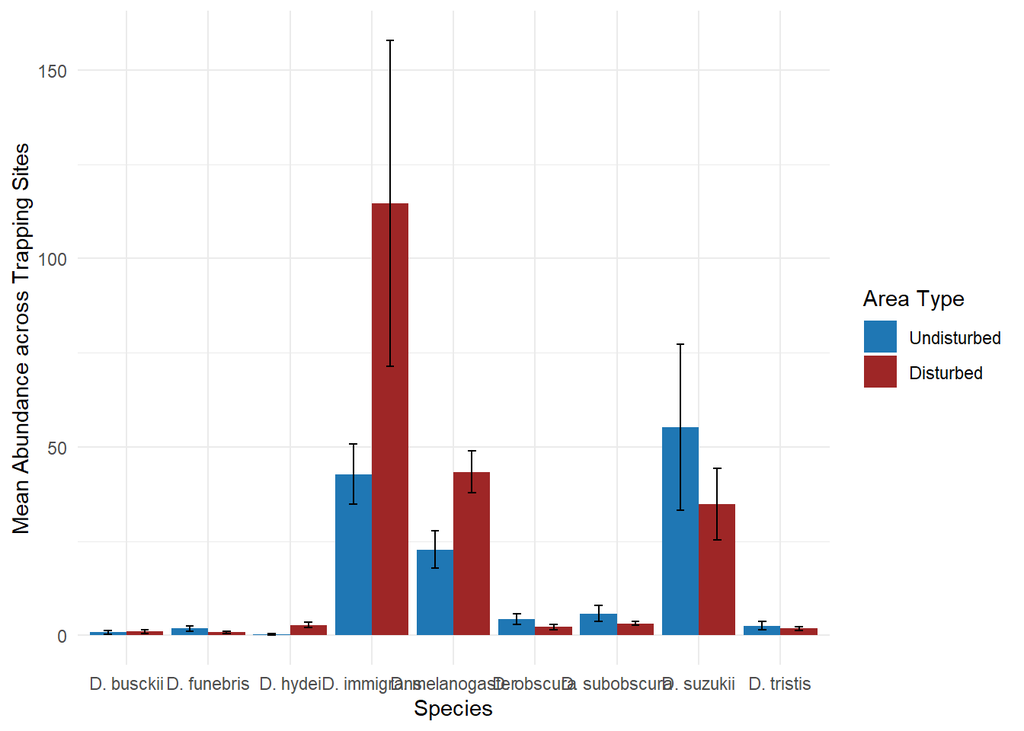

```r
  ggplot(trap_abundance_summary_data, aes(x = species, y = mean_abundance, fill = area_type)) +
    geom_bar(stat = "identity", position = "dodge") +
    geom_errorbar(aes(ymin = mean_abundance - se, ymax = mean_abundance + se), width = 0.2, position = position_dodge(width = 0.9)) +
    labs(y = "Mean Abundance across Trapping Sites",
         x = "Species",
         fill = "Area Type") +
    scale_fill_manual(values = c("N" = "#1F77B4", "U" = "#9E2626"), labels = c("N" = "Undisturbed", "U" = "Disturbed")) +
    scale_x_discrete(labels = c("immi"="D. immigrans","mel"="D. melanogaster", "suz"="D. suzukii", "sub"="D. subobscura", "obs"="D. obscura", "bus"="D. busckii", "fun"="D. funebris", "hyd"="D. hydei", "tris"="D. tristis", "NA"="NA")) +
    theme_minimal()
```

Figure 3:

To create a plot containing a bar chart comparing each of the diversity index values between disturbed and undisturbed sites, we start by ensuring that all of the diversity indices are stored as numeric values.

```r
trap_no_abundance_noNA <- trap_no_abundance_noNA %>%
    mutate(across(c(simpsons_index, shannon_index, berger_parker_index, mcIntosh_index), as.numeric))
```

Next, we re-organise the data and add the mean and standard errors as new columns.

```r
  summary_diversity_data <- trap_no_abundance_noNA %>%
    pivot_longer(cols = c(simpsons_index, shannon_index, berger_parker_index, mcIntosh_index),
                 names_to = "diversity_index",
                 values_to = "value") %>%
    group_by(area_type, diversity_index) %>%
    summarise(mean_value = mean(value),
              se = sd(value) / sqrt(n()),
              .groups = "drop")
```

Now, we create individual charts for each diversity index.

Simpson’s Index:

```r
  plot_simpsons <- ggplot(summary_diversity_data %>% filter(diversity_index == "simpsons_index"),
                          aes(x = area_type, y = mean_value, fill = area_type)) +
    geom_bar(stat = "identity", position = position_dodge(width = 0.9)) +
    geom_errorbar(aes(ymin = mean_value - se, ymax = mean_value + se),
                  position = position_dodge(width = 0.9),
                  width = 0.2) +
    labs(y = "Mean Diversity Index Value", fill = "Area Type", x = "")+
    scale_fill_manual(values = c("N" = "#4A2354", "U" = "#BB8FCE"), labels = c("N" = "Undisturbed", "U" = "Disturbed"))+
    theme_minimal()+
    ylim(0,1)+
    scale_x_discrete(labels = c("N"="Undisturbed","U"="Disturbed"))+
    guides(fill='none')
```

Shannon’s Index:

```r
  plot_shannon <- ggplot(summary_diversity_data %>% filter(diversity_index == "shannon_index"),
                         aes(x = area_type, y = mean_value, fill = area_type)) +
    geom_bar(stat = "identity", position = position_dodge(width = 0.9)) +
    geom_errorbar(aes(ymin = mean_value - se, ymax = mean_value + se),
                  position = position_dodge(width = 0.9),
                  width = 0.2) +
    labs(y = "Mean Diversity Index Value", fill = "Area Type", x = "") +
    scale_fill_manual(values = c("N" = "#0B5345", "U" = "#73C6B6"), labels = c("N" = "Undisturbed", "U" = "Disturbed"))+
    theme_minimal()+
    scale_x_discrete(labels = c("N"="Undisturbed","U"="Disturbed"))+
    guides(fill='none')
```

Berger-Parker Index:

```r
  plot_berger_parker <- ggplot(summary_diversity_data %>% filter(diversity_index == "berger_parker_index"),
                               aes(x = area_type, y = mean_value, fill = area_type)) +
    geom_bar(stat = "identity", position = position_dodge(width = 0.9)) +
    geom_errorbar(aes(ymin = mean_value - se, ymax = mean_value + se),
                  position = position_dodge(width = 0.9),
                  width = 0.2) +
    labs(y = "Mean Diversity Index Value", fill = "Area Type", x = "")+
    scale_fill_manual(values = c("N" = "#7D6608", "U" = "#F7DC6F"), labels = c("N" = "Undisturbed", "U" = "Disturbed"))+
    theme_minimal()+
    ylim(0,1)+
    scale_x_discrete(labels = c("N"="Undisturbed","U"="Disturbed"))+
    guides(fill='none')
```

McIntosh’s Index:

```r
  plot_mcintosh <- ggplot(summary_diversity_data %>% filter(diversity_index == "mcIntosh_index"),
                          aes(x = area_type, y = mean_value, fill = area_type)) +
    geom_bar(stat = "identity", position = position_dodge(width = 0.9)) +
    geom_errorbar(aes(ymin = mean_value - se, ymax = mean_value + se),
                  position = position_dodge(width = 0.9),
                  width = 0.2) +
    labs(y = "Mean Diversity Index Value", x = "") +
    scale_fill_manual(values = c("N" = "#6E2C00", "U" = "#E59866"), labels = c("N" = "Undisturbed", "U" = "Disturbed"))+
    theme_minimal()+
    ylim(0,1)+
    scale_x_discrete(labels = c("N"="Undisturbed","U"="Disturbed"))+
    guides(fill='none')
```

Next, we combine these charts into a single plot.

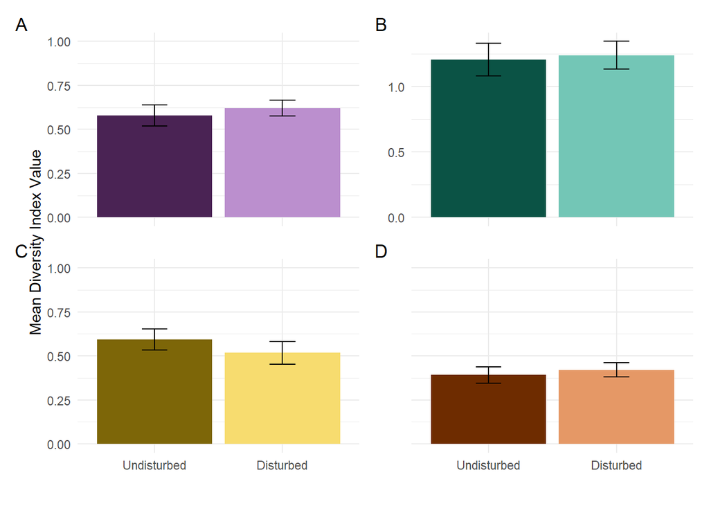

```r
 combined_plots <- plot_simpsons + plot_shannon + plot_berger_parker + plot_mcintosh


 combined_plots + plot_layout(guides = 'collect', axes = 'collect') + plot_annotation(tag_levels = 'A')
```

Table 2:

To create a table of the spatial autocorrelation (Global Moran’s I) results, data from the ArcGIS Pro analyses was entered into a Microsoft Excel spreadsheet. We then import this.

```r
autocor_path <- "./data/autocorrelation_results.csv"
autocor_data <- read_csv(autocor_path)
```

Next, we create a table using this data.

```r
autocor_data %>%
  flextable %>%
  width(., width = (6.49605/(ncol(autocor_data)))) %>%
  italic(italic=T, part = "body", j = "Species") %>%
  color(color="#4DAC23", j = "p-value", i = 4)
```

| Species | Moran's Index | Expected Index | Variance | z-score | p-value |
| --- | --- | --- | --- | --- | --- |
| D. busckii | -0.35 | -0.11 | 0.04 | -1.26 | 0.206 |
| D. funebris | 0.19 | -0.11 | 0.04 | 1.55 | 0.121 |
| D. hydei | -0.05 | -0.11 | 0.04 | 0.33 | 0.741 |
| D. immigrans | 0.10 | -0.11 | 0.01 | 2.10 | 0.036 |
| D. melanogaster | 0.24 | -0.11 | 0.03 | 1.93 | 0.053 |
| D. obscura | -0.07 | -0.11 | 0.03 | 0.23 | 0.818 |
| D. subobscura | -0.10 | -0.11 | 0.03 | 0.07 | 0.944 |
| D. suzukii | -0.12 | -0.11 | 0.03 | -0.05 | 0.960 |
| D. tristis | -0.24 | -0.11 | 0.02 | -0.91 | 0.364 |